# FigureYa236circGroup

**Author(s)**: Xiaofan Lu  
**Reviewer(s)**: Ying Ge,Hui Huang  
**Date**: 2025-11-20

## 1 Academic Citation

If you use this code in your work or research, we kindly request that you cite our publication:

Xiaofan Lu, et al. (2025). FigureYa: A Standardized Visualization Framework for Enhancing Biomedical Data Interpretation and Research Efficiency. iMetaMed. https://doi.org/10.1002/imm3.70005

If you use circlize in published research, please cite:

Gu, Z. circlize implements and enhances circular visualization in R. Bioinformatics 2014.

If you use ComplexHeatmap in published research, please cite:

Zuguang Gu, et al., Complex heatmaps reveal patterns and correlations in multidimensional genomic data, Bioinformatics, 2016.

Zuguang Gu. Complex Heatmap Visualization, iMeta, 2022.

## 2 需求描述 Requirement Description

用圆圈图的方式展示不同分组的关系。网上没有找到可以实现的代码。最好是R语言做。

Draw this diagram to show the relationship between different groups in the form of a circle diagram. There is no code available online that can be implemented. It’s best to do it in R.

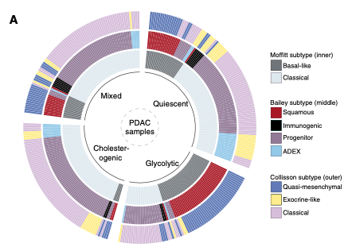

From https://clincancerres.aacrjournals.org/content/26/1/135

Figure 3. Alignment of PDAC metabolic subgroups with known gene expression subtypes. A, Overlay of metabolic profiles (inner ring) with PDAC expression subtypes (outer rings) based on the Moffitt and colleagues’ (4), Bailey and colleagues’ (2), and Collisson and colleagues’ (3) classifications.

## 3 应用场景 Application Scenario

将亚型（或其他分类变量）之间的映射关系（一致性）以圈状热图注释的方式展现。

我们还实现过例文的Figure 1ABC，通过基因共识聚类选择共表达的基因集，随后根据表达谱中位数划分四类样本，可参考`FigureYa202consensusGene`

The mapping (agreement) between subtypes (or other categorical variables) is presented as a circular heatmap annotation.

We have also crowdsourced Figure 1ABC for example, which selects co-expressed gene sets through gene consensus clustering, and then divides four types of samples according to the median expression profile, as shown in ‘FigureYa202consensusGene’

## 4 环境设置 Environment Setting

```r
source("install_dependencies.R")  # 加载依赖安装脚本 # Load dependency installation script
```

[output not shown]

```r
library(circlize)        # 用于绘制环形图 # For creating circular plots
library(gridBase)        # 提供基础图形功能 # Provides basic graphic functions
library(grid)            # 用于图形布局 # For graphical layout
library(ComplexHeatmap)  # 用于绘制复杂热图 # For creating complex heatmaps
library(SimDesign)       # 提供模拟设计和分析功能 # Provides simulation design and analysis functions

Sys.setenv(LANGUAGE = "en") # 显示英文报错信息 # Messages are displayed in English
options(stringsAsFactors = FALSE) # 禁止字符型数据自动转换为因子型 # Prevent automatic conversion of character data to factors
```

## 5 输入文件 Input file

easy_input.txt，多组分类信息。也可用于FigureYa25Sankey，画成桑基图。

easy_input.txt. Multiple groups of classified information. It can also be used for FigureYa25Sankey, which is drawn as a Sankey diagram.

```r
# 加载亚型数据并依次排序
# Load the subtype data and sort them in turn
subt <- read.table("easy_input.txt", sep = "\t", row.names = 1, check.names = F, stringsAsFactors = F, header = T)
head(subt)
```

```
##       TCGA_subtype Moffitt_subtype Bailey subtype Collisson subtype
## P1 Cholesterogenic      Basal-like       Squamous Quasi-mesenchymal
## P2 Cholesterogenic      Basal-like       Squamous Quasi-mesenchymal
## P3 Cholesterogenic      Basal-like       Squamous Quasi-mesenchymal
## P4 Cholesterogenic      Basal-like       Squamous Quasi-mesenchymal
## P5 Cholesterogenic      Basal-like    Immunogenic Quasi-mesenchymal
## P6 Cholesterogenic      Basal-like    Immunogenic         Classical
```

```r
# 亚型依次排序
# Isotypes are sorted in order
subt <- subt[order(subt$TCGA_subtype,
                   subt$Moffitt_subtype,
                   subt$`Bailey subtype`,
                   subt$`Collisson subtype`), ]
```

## 6 开始画图 Start drawing

用circlize画图，参考作者的电子书https://jokergoo.github.io/circlize_book/book/。

看每段开头的注释，了解每段的功能，就可以灵活修改分组的数量、颜色了。

Draw with circlize, referring to the author’s e-book https://jokergoo.github.io/circlize_book/book/.

Look at the comments at the beginning of each paragraph to understand the function of each paragraph, and you can flexibly modify the number and color of the grouping.

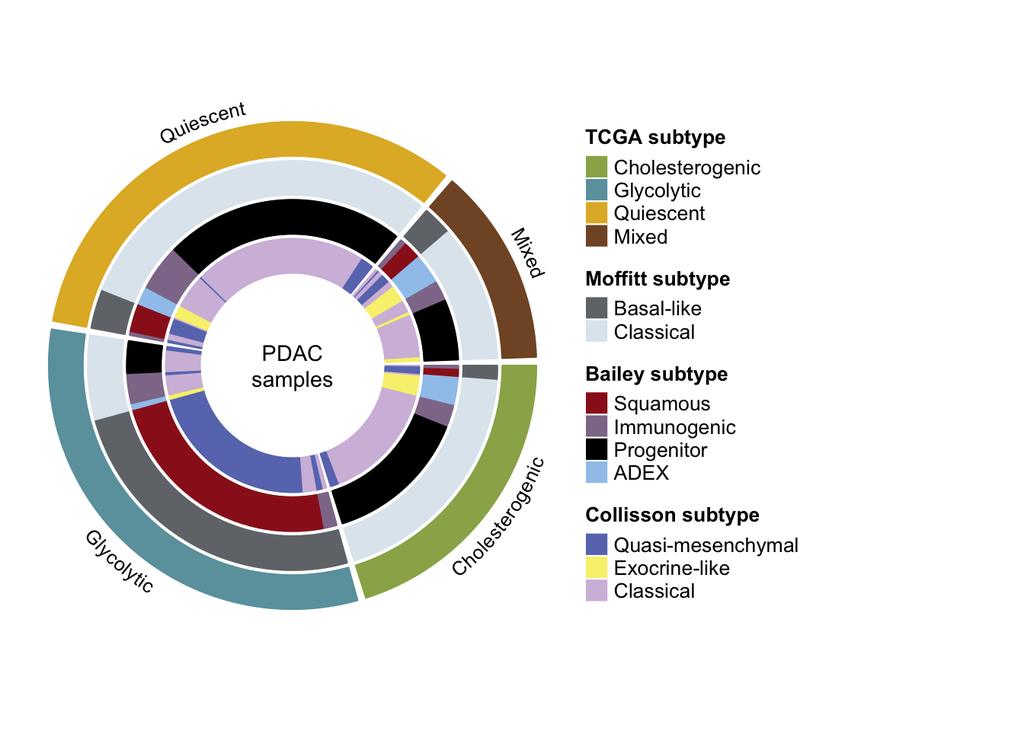

```r
# 设置各个亚型的颜色
# Set the color of each subtype
subtype1.col <- c("#9AAF57", "#6AA1AB", "#E1B52E", "#81552E")
subtype2.col <- c("#717579", "#DFE8EE")
subtype3.col <- c("#9B1C1F", "#8F7999", "black", "#9FC6EC")
subtype4.col <- c("#6978BC", "#F7F07C", "#D3BDDC")

# 映射各亚型各水平的颜色
# Map the colors of each subtype and each level
col_subt1 <- c("Cholesterogenic" = subtype1.col[1],
               "Glycolytic" = subtype1.col[2],
               "Quiescent" = subtype1.col[3],
               "Mixed" = subtype1.col[4])
col_subt2 <- c("Basal-like" = subtype2.col[1],
               "Classical" = subtype2.col[2])
col_subt3 <- c("Squamous" = subtype3.col[1],
               "Immunogenic" = subtype3.col[2],
               "Progenitor" = subtype3.col[3],
               "ADEX" = subtype3.col[4])
col_subt4 <- c("Quasi-mesenchymal" = subtype4.col[1],
               "Exocrine-like" = subtype4.col[2],
               "Classical" = subtype4.col[3])

# 创建图例
# Create a legend
lgd_subt1 <- Legend(title = "TCGA subtype", # 图例title # Legend title
                    at = names(col_subt1), # 图例的水平 # The level of the legend
                    legend_gp = gpar(fill = col_subt1)) # 图例所填充的颜色 # The color of the legend filled
lgd_subt2 <- Legend(title = "Moffitt subtype",
                    at = names(col_subt2),
                    legend_gp = gpar(fill = col_subt2))
lgd_subt3 <- Legend(title = "Bailey subtype",
                    at = names(col_subt3),
                    legend_gp = gpar(fill = col_subt3))
lgd_subt4 <- Legend(title = "Collisson subtype",
                    at = names(col_subt4),
                    legend_gp = gpar(fill = col_subt4))

# 自定义函数，正式合并图像和图例
# Custom functions to formally merge images and legends
circlize_plot = function() {
  circos.heatmap(subt$TCGA_subtype,
                 split = factor(subt$TCGA_subtype,levels = c("Cholesterogenic", "Glycolytic", "Quiescent", "Mixed")), # 按照亚型因子顺序排列 # Listed in order of subtype factor
                 col = col_subt1,
                 track.height = 0.14,
                 show.sector.labels = TRUE) # 显示区块名 # Displays the block name
  circos.heatmap(subt$Moffitt_subtype,
                 split = factor(subt$Moffitt_subtype, levels = c("Basal-like", "Classical")),
                 col = col_subt2,
                 track.height = 0.14)
  circos.heatmap(subt$`Bailey subtype`,
                 split = factor(subt$`Bailey subtype`, levels = c("Squamous", "Immunogenic", "Progenitor", "ADEX")),
                 col = col_subt3,
                 track.height = 0.14)
  circos.heatmap(subt$`Collisson subtype`,
                 split = factor(subt$`Collisson subtype`, levels = c("Quasi-mesenchymal", "Exocrine-like", "Classical")),
                 col = col_subt4,
                 track.height = 0.14)
  # 注意：circos.clear() 在函数外部调用，确保每次绘图前状态是干净的
  # Note: circos.clear() is called outside the function to ensure the state is clean before each plot
}

## 开始画图 ## Start drawing
plot.new() # 请从这句开始到你想修改/理解的那行代码，整段运行 # Please start with this sentence and run the whole line of code you want to modify/understand
circle_size = unit(0.8, "snpc") # snpc会设置一个正方形的区域 # SNPC will set a square area
pushViewport(viewport(x = 0, y = 0.5,
                      width = circle_size,
                      height = circle_size,
                      just = c("left", "center")))
par(omi = gridOMI(), new = TRUE)
circos.clear() # 确保 circlize 状态是干净的 # Ensure circlize state is clean
suppressMessages(suppressWarnings(circlize_plot()))

# 添加正中心的文字
# Add text in the center
text(0, 0, "PDAC\nsamples", cex = 0.9) # 添加正中心的文字 # Add text in the center
upViewport()

# 画图例
# Draw a legend
lgd_list <- packLegend(lgd_subt1,
                       lgd_subt2,
                       lgd_subt3,
                       lgd_subt4,
                       max_height = unit(0.9*dev.size()[2], "inch"))
draw(lgd_list, x = circle_size, just = "left")
```

```r
# 直接保存图像到本地
# Save images directly to your local computer
dev.copy2pdf(file = "subtype circos plot.pdf")
```